# Analysis of Activity Monitoring Data

## Imputing Missing Values

The following code returns the total number of rows in the main data set that contain missing values.

```r
nrow(activity.data[activity.data$steps == "NA", ])
```

```
## [1] 2304
```

```r
activity.data2 <- activity.data
for (i in 1: nrow(activity.data2)){
        if(is.na(activity.data2[i,1])){
                activity.data2[i,1] <- daily.activity[match(activity.data2[i,3], daily.activity$interval),2]
        }
}
str(activity.data2)
```

```
## 'data.frame':    17568 obs. of  3 variables:
##  $ steps   : num  1.717 0.3396 0.1321 0.1509 0.0755 ...
##  $ date    : Date, format: "2012-10-01" "2012-10-01" ...
##  $ interval: int  0 5 10 15 20 25 30 35 40 45 ...
```

The data set of the total number of steps per day was created using the data without missing values.

```r
steps.per.day2 <- aggregate.data.frame(activity.data2$steps, by = list(date = activity.data2$date), FUN = sum)
names(steps.per.day2)= c("date", "total.steps")
str(steps.per.day2)
```

```
## 'data.frame':    61 obs. of  2 variables:
##  $ date       : Date, format: "2012-10-01" "2012-10-02" ...
##  $ total.steps: num  10766 126 11352 12116 13294 ...
```

The number of steps taken each day is represented as a histogram.

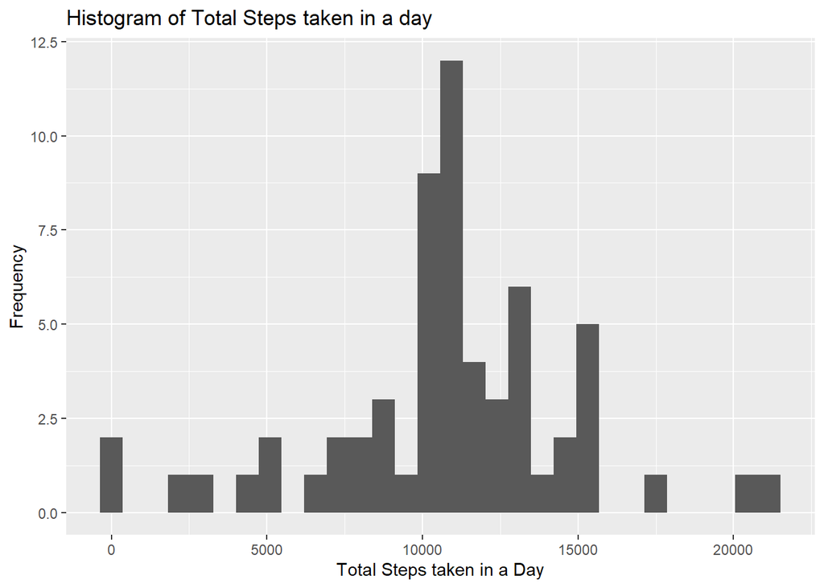

```r
library(ggplot2)
qplot(x = steps.per.day2$total.steps, xlab = "Total Steps taken in a Day", ylab = "Frequency", main = "Histogram of Total Steps taken in a day")
```

The mean number of steps taken per day was calculated

```r
mean(steps.per.day2$total.steps, na.rm = TRUE)
```

```
## [1] 10766.19
```

The median number of steps taken per day was calculated

```r
median(steps.per.day2$total.steps, na.rm = TRUE)
```

```
## [1] 10766.19
```

```r
activity.data2$date <- as.Date(activity.data2$date, format = "%Y-%m-%d")
activity.data2$day <- weekdays(activity.data2$date)
activity.data2$day.type <- c(rep(0, nrow(activity.data2)))
 for (i in 1: nrow(activity.data2)){
        if (activity.data2[i, ]$day == "Sunday"| activity.data2[i, ]$day == "Saturday"){
        activity.data2[i,]$day.type <- "weekend"
        }
        else{
                activity.data2[i, ]$day.type <- "weekday"
        }
}
activity.data2$day.type <- as.factor(activity.data2$day.type)
str(activity.data2)
```

```
## 'data.frame':    17568 obs. of  5 variables:
##  $ steps   : num  1.717 0.3396 0.1321 0.1509 0.0755 ...
##  $ date    : Date, format: "2012-10-01" "2012-10-01" ...
##  $ interval: int  0 5 10 15 20 25 30 35 40 45 ...
##  $ day     : chr  "Monday" "Monday" "Monday" "Monday" ...
##  $ day.type: Factor w/ 2 levels "weekday","weekend": 1 1 1 1 1 1 1 1 1 1 ...
```

The following code creates the data frame with average daily activty across intervals for weekdays and weekends.

```r
daily.activity2 <- aggregate(activity.data2$steps,
                             by = list(activity.data2$interval,
                                       activity.data2$day.type), FUN = mean)
names(daily.activity2) <- c("interval", "day.type","mean.steps")
str(daily.activity2)
```

```
## 'data.frame':    576 obs. of  3 variables:
##  $ interval  : int  0 5 10 15 20 25 30 35 40 45 ...
##  $ day.type  : Factor w/ 2 levels "weekday","weekend": 1 1 1 1 1 1 1 1 1 1 ...
##  $ mean.steps: num  2.251 0.445 0.173 0.198 0.099 ...
```

The following code creates a panel time plot for average daily activiy.

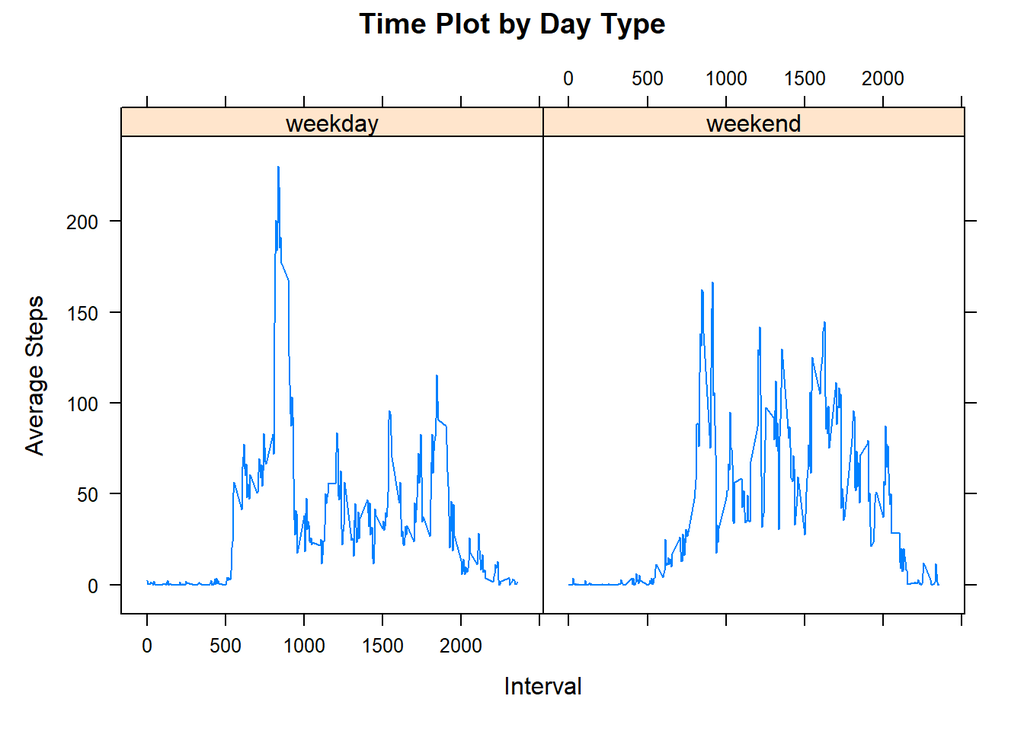

```r
library(lattice)
xyplot(mean.steps~interval|day.type, data = daily.activity2, type = "l", xlab = "Interval", ylab="Average Steps", main= "Time Plot by Day Type")
```